# 0321

```r
#####
# set up the environment
#####
# load packages
library(brms)
library(rethinking)
options(mc.cores = parallel::detectCores())
rstan_options(auto_write = TRUE)

# adjust the plot region for viewing on the projector in class
options(repr.plot.height=5)
```

[output not shown]

## Preparing the data

```r
d <- read.csv("../site/data/t_star_student_grade1_2l.csv")
head(d)
dim(d)
```

| student_id | teacher_id | school_id | student_born | student_female | student_race_ethnicity | student_re_white | student_re_black | student_re_asian | student_re_hispanic | ⋯ | teacher_degree | teacher_exper | teacher_female | teacher_race_ethnicity | teacher_re_white | teacher_re_black | teacher_re_asian | teacher_re_hispanic | teacher_re_native_american | teacher_re_other |
| --- | --- | --- | --- | --- | --- | --- | --- | --- | --- | --- | --- | --- | --- | --- | --- | --- | --- | --- | --- | --- |
| 11582 | 11203804 | 112038 | 1979.403 | FALSE | Black | FALSE | TRUE | FALSE | FALSE | ⋯ | Bachelors | 7 | TRUE | Black | FALSE | TRUE | FALSE | FALSE | FALSE | FALSE |
| 18988 | 11203804 | 112038 | 1980.254 | TRUE | White | TRUE | FALSE | FALSE | FALSE | ⋯ | Bachelors | 7 | TRUE | Black | FALSE | TRUE | FALSE | FALSE | FALSE | FALSE |
| 15004 | 11203804 | 112038 | 1980.284 | FALSE | Black | FALSE | TRUE | FALSE | FALSE | ⋯ | Bachelors | 7 | TRUE | Black | FALSE | TRUE | FALSE | FALSE | FALSE | FALSE |
| 16823 | 11203804 | 112038 | 1980.675 | FALSE | White | TRUE | FALSE | FALSE | FALSE | ⋯ | Bachelors | 7 | TRUE | Black | FALSE | TRUE | FALSE | FALSE | FALSE | FALSE |
| 16118 | 11203804 | 112038 | 1980.514 | TRUE | White | TRUE | FALSE | FALSE | FALSE | ⋯ | Bachelors | 7 | TRUE | Black | FALSE | TRUE | FALSE | FALSE | FALSE | FALSE |
| 10575 | 11203804 | 112038 | 1979.581 | FALSE | Black | FALSE | TRUE | FALSE | FALSE | ⋯ | Bachelors | 7 | TRUE | Black | FALSE | TRUE | FALSE | FALSE | FALSE | FALSE |

1. 6684

2. 35

```r
# select 20 schools
t_ids <- unique(d$teacher_id)
t_ids <- sample(t_ids,20)
t_ids
```

1. 16922919

2. 18939605

3. 16928007

4. 25789907

5. 24469711

6. 24480613

7. 24479607

8. 20144910

9. 24475512

10. 16921907

11. 24472311

12. 24472308

13. 24479907

14. 25288508

15. 26293706

16. 22860608

17. 16519906

18. 23462811

19. 18939607

20. 20144912

```r
# subset the data
d <- d[d$teacher_id %in% t_ids,]
dim(d)
```

1. 405

2. 35

```r
# keep only students who are white or Black
d <- d[d$student_re_white | d$student_re_black,]
dim(d)
```

1. 403

2. 35

```r
# create a standardized age variable
st <- function(x){
    (x-mean(x,na.rm=TRUE))/sd(x,na.rm=TRUE)
}

d$student_age_s <- st(-d$student_born)
```

## Standard linear regression

To get our feet wet, we'll start with a standard linear regression. This can be specified in `brms` exactly as it is with the `lm()` function, but using the `brm()` function instead.

```r
m_0 <- student_reading_score ~ student_age_s + student_re_black + student_female
fit_0 <- brm(formula=m_0,data=d)
```

```r
summary(fit_0)
```

```
 Family: gaussian
  Links: mu = identity; sigma = identity
Formula: student_reading_score ~ student_age_s + student_re_black + student_female
   Data: d (Number of observations: 398)
Samples: 4 chains, each with iter = 2000; warmup = 1000; thin = 1;
         total post-warmup samples = 4000

Population-Level Effects:
                     Estimate Est.Error l-95% CI u-95% CI Eff.Sample Rhat
Intercept              532.38      4.22   523.90   540.68       4461 1.00
student_age_s           -4.04      2.56    -9.11     0.98       4898 1.00
student_re_blackTRUE   -38.62      5.14   -48.87   -28.45       4855 1.00
student_femaleTRUE       9.41      5.42    -1.03    20.02       4448 1.00

Family Specific Parameters:
      Estimate Est.Error l-95% CI u-95% CI Eff.Sample Rhat
sigma    50.36      1.82    46.91    54.16       4685 1.00

Samples were drawn using sampling(NUTS). For each parameter, Eff.Sample
is a crude measure of effective sample size, and Rhat is the potential
scale reduction factor on split chains (at convergence, Rhat = 1).
```

We get estimates and confidence intervals for the "population-level" effects, as well as a estimates for sigma. The model also reports two important pieces of diagnostic information.

**Eff.Sample:** This refers to the "effective" posterior sample size. Autocorrelation in the HMC chain can mean that you need a larger sample to get good estimates for the mean and credible intervals on your parameters. Usually an effective sample of a few hundred is sufficient to get good values for the mean, median, and 95% credible intervals. However if you want wider credible intervals (like 99%, say), you will want a bigger effective sample size.

**Rhat:** When you run multiple HMC chains to estimate your model (this is very good practice), "Rhat" ($\hat{R}$) is a measure of how much the samples from those chains look like they are from the same posterior. You want $\hat{R}$ to be close to 1.0. If it is bigger than 1.2 or so, you should start to worry that your chains haven't converged and you should specify more iterations and a longer warmup. `brm` should warn you about this but it is a good idea to check.

```r
# compare to lm
summary(lm(m_0,data=d))
```

```
Call:
lm(formula = m_0, data = d)

Residuals:
     Min       1Q   Median       3Q      Max
-123.702  -37.997   -4.373   34.553  126.371

Coefficients:
                     Estimate Std. Error t value Pr(>|t|)
(Intercept)           532.476      4.174 127.564  < 2e-16 ***
student_age_s          -4.062      2.589  -1.569   0.1175
student_re_blackTRUE  -38.727      5.149  -7.521  3.7e-13 ***
student_femaleTRUE      9.369      5.117   1.831   0.0679 .
---
Signif. codes:  0 ‘***’ 0.001 ‘**’ 0.01 ‘*’ 0.05 ‘.’ 0.1 ‘ ’ 1

Residual standard error: 50.2 on 394 degrees of freedom
  (5 observations deleted due to missingness)
Multiple R-squared:  0.1344,	Adjusted R-squared:  0.1278
F-statistic:  20.4 on 3 and 394 DF,  p-value: 2.63e-12
```

How was that so easy? `brm()` tries to take care of everything for you, which is convenient for exploration, but can hide a lot of what is going on with your model.

To see the priors that the function chose for us, we use the `prior_summary()` function:

```r
prior_summary(fit_0)
```

| prior | class | coef | group | resp | dpar | nlpar | bound |
| --- | --- | --- | --- | --- | --- | --- | --- |
|  | b |  |  |  |  |  |  |
|  | b | student_age_s |  |  |  |  |  |
|  | b | student_femaleTRUE |  |  |  |  |  |
|  | b | student_re_blackTRUE |  |  |  |  |  |
| student_t(3, 516, 53) | Intercept |  |  |  |  |  |  |
| student_t(3, 0, 53) | sigma |  |  |  |  |  |  |

By default, `brm()` uses improper flat priors for the slope coefficients. This is a little bit controversial, but works well enough in practice.

The intercept is treated differently. It is given a t-distributed prior, centered at the mean of the outcome variable. This is also a somewhat problematic choice in principle: basing priors on your data can defeat the purpose of the prior. The standard deviation is quite wide, and the t distribution (with 3 degrees of freedom) has very fat tails, so this won't tend to induce any bias.

Still, let's put some more principled priors on our coefficients.

```r
# make a new fit using the same formula but different priors
fit_0p <- brm(
    formula=m_0,
    data=d,
    prior=c(
        set_prior("normal(500,100)",class="Intercept"),
        set_prior("normal(0,50)",class='b')
    )
)
```

```r
# check out estimates and priors
summary(fit_0p)
prior_summary(fit_0p)
```

```
 Family: gaussian
  Links: mu = identity; sigma = identity
Formula: student_reading_score ~ student_age_s + student_re_black + student_female
   Data: d (Number of observations: 398)
Samples: 4 chains, each with iter = 2000; warmup = 1000; thin = 1;
         total post-warmup samples = 4000

Population-Level Effects:
                     Estimate Est.Error l-95% CI u-95% CI Eff.Sample Rhat
Intercept              532.35      4.11   524.36   540.48       4659 1.00
student_age_s           -4.02      2.68    -9.18     1.21       4693 1.00
student_re_blackTRUE   -38.41      5.19   -48.38   -28.32       4420 1.00
student_femaleTRUE       9.37      5.10    -0.49    19.26       4751 1.00

Family Specific Parameters:
      Estimate Est.Error l-95% CI u-95% CI Eff.Sample Rhat
sigma    50.28      1.78    46.97    53.86       4650 1.00

Samples were drawn using sampling(NUTS). For each parameter, Eff.Sample
is a crude measure of effective sample size, and Rhat is the potential
scale reduction factor on split chains (at convergence, Rhat = 1).
```

| prior | class | coef | group | resp | dpar | nlpar | bound |
| --- | --- | --- | --- | --- | --- | --- | --- |
| normal(0,50) | b |  |  |  |  |  |  |
|  | b | student_age_s |  |  |  |  |  |
|  | b | student_femaleTRUE |  |  |  |  |  |
|  | b | student_re_blackTRUE |  |  |  |  |  |
| normal(500,100) | Intercept |  |  |  |  |  |  |
| student_t(3, 0, 53) | sigma |  |  |  |  |  |  |

## Adding random effects

Let's add some random effects, first just the intercept:

$$ S_{ik} \sim \mathrm{Norm}(\mu_{ik},\sigma)\\ \mu_{ik} = \beta_{0k} + \beta_{1}Age_i + \beta_{2}Female_i + \beta_{3}Black_i\\ \beta_{0k} = \gamma_{00} + \eta_{0k} $$

```r
# you can break the formula up onto multiple lines, as long as
# each line ends with an operation like `~` or `+`
m_1 <- student_reading_score ~
    student_age_s + student_re_black + student_female +
    (1 | teacher_id)

fit_1 <- brm(
    formula=m_1,
    data=d,
    prior=c(
        set_prior("normal(500,100)",class="Intercept"),
        set_prior("normal(0,50)",class='b')
    )
)
```

```r
summary(fit_1)
```

```
 Family: gaussian
  Links: mu = identity; sigma = identity
Formula: student_reading_score ~ student_age_s + student_re_black + student_female + (1 | teacher_id)
   Data: d (Number of observations: 398)
Samples: 4 chains, each with iter = 2000; warmup = 1000; thin = 1;
         total post-warmup samples = 4000

Group-Level Effects:
~teacher_id (Number of levels: 20)
              Estimate Est.Error l-95% CI u-95% CI Eff.Sample Rhat
sd(Intercept)    24.89      5.22    16.34    36.57       1209 1.00

Population-Level Effects:
                     Estimate Est.Error l-95% CI u-95% CI Eff.Sample Rhat
Intercept              527.61      7.23   513.07   541.77       1434 1.00
student_age_s           -3.63      2.40    -8.40     1.04       4714 1.00
student_re_blackTRUE   -25.94      7.11   -39.63   -11.89       2678 1.00
student_femaleTRUE      10.00      4.68     0.82    19.20       4416 1.00

Family Specific Parameters:
      Estimate Est.Error l-95% CI u-95% CI Eff.Sample Rhat
sigma    45.41      1.68    42.27    49.00       4738 1.00

Samples were drawn using sampling(NUTS). For each parameter, Eff.Sample
is a crude measure of effective sample size, and Rhat is the potential
scale reduction factor on split chains (at convergence, Rhat = 1).
```

The summary now has some information on "group-level" (as opposed to "population-level") effects. Because we only have a random intercept the information on this is limited to a standard deviation. In the model above, this corresponds to the standard deviation of the random effects, $\phi_0=SD(\eta_{0k})$. The estimate puts it at around 25, which tells us the scale of variation between classes in average test score. 100 points (about four standard deviations) will cover about 95% of the variation in average scores between the classes.

Before we move on, let's check out the priors to see about the ones that we didn't set.

```r
prior_summary(fit_1)
```

| prior | class | coef | group | resp | dpar | nlpar | bound |
| --- | --- | --- | --- | --- | --- | --- | --- |
| normal(0,50) | b |  |  |  |  |  |  |
|  | b | student_age_s |  |  |  |  |  |
|  | b | student_femaleTRUE |  |  |  |  |  |
|  | b | student_re_blackTRUE |  |  |  |  |  |
| normal(500,100) | Intercept |  |  |  |  |  |  |
| student_t(3, 0, 53) | sd |  |  |  |  |  |  |
|  | sd |  | teacher_id |  |  |  |  |
|  | sd | Intercept | teacher_id |  |  |  |  |
| student_t(3, 0, 53) | sigma |  |  |  |  |  |  |

`brms` differentiates between the "fixed" and "random" effects in a model. The fixed effects are the coefficient estimates on age, sex, and race, as well as the intercept. The random effects describe the variation from classroom to classroom.

One way to examine these is to use the `fixef()` and `ranef()` functions:

```r
fixef(fit_1)
```

|  | Estimate | Est.Error | Q2.5 | Q97.5 |
| --- | --- | --- | --- | --- |
| Intercept | 527.611323 | 7.229921 | 513.0700744 | 541.767269 |
| student_age_s | -3.626869 | 2.397058 | -8.3955267 | 1.043805 |
| student_re_blackTRUE | -25.935105 | 7.111579 | -39.6264968 | -11.885768 |
| student_femaleTRUE | 10.003642 | 4.680643 | 0.8194995 | 19.197878 |

```r
# jupyter is very bad at displaying arrays with more than 2 'dimensions'
ranef(fit_1)
dim(ranef(fit_1)$teacher_id)
# look at just the first class:
ranef(fit_1)$teacher_id[1,,]
```

**$teacher_id** =

1. 41.3966572670716

2. -0.999090405948943

3. 16.3750198388537

4. -7.85021862165541

5. 0.930837480631136

6. -16.1689123719714

7. 30.1971349052044

8. -1.67450784353778

9. 32.5592794906878

10. -13.8989320862484

11. 3.01699701881755

12. -33.6692059241701

13. -2.9431040734733

14. -21.0105724803961

15. -14.1496320111013

16. 11.4657443916981

17. -22.2638927550665

18. -2.84205895575994

19. -26.8240912541666

20. 29.7214884592367

21. 11.2301839461058

22. 10.7278996384634

23. 10.5139428985235

24. 10.3160519491882

25. 11.3454599830487

26. 10.8247461656927

27. 10.4944439536928

28. 10.4213459157233

29. 12.453885816107

30. 10.5461378219015

31. 11.6296708461136

32. 11.1683457229562

33. 12.1200733902034

34. 11.431044170876

35. 11.7016318014714

36. 11.1051551639807

37. 11.1482976441286

38. 9.62631882574914

39. 10.8058743798693

40. 12.4299883617594

41. 20.4394971840443

42. -21.3225523965236

43. -3.47934662286321

44. -27.7063080488145

45. -21.8494937166405

46. -37.3857507788958

47. 9.89553931334397

48. -22.8621742768726

49. 8.62543630997898

50. -34.819114508588

51. -19.6164196770391

52. -55.3767048873867

53. -27.0236784683109

54. -43.7891309145397

55. -37.8720682126336

56. -10.8141379687289

57. -44.295069111384

58. -22.1344057062813

59. -48.3387624945961

60. 6.28966680801712

61. 64.117808233532

62. 20.189138761355

63. 37.1398221646336

64. 12.4738181385723

65. 23.2519189972142

66. 5.22917603497827

67. 50.9969290534614

68. 18.4585356591316

69. 57.373710307992

70. 6.95922174350838

71. 25.3722758337163

72. -12.5234769334799

73. 20.4667145029159

74. 1.80686680781631

75. 8.36316141505907

76. 32.9443945062531

77. -0.924293133230679

78. 15.7970834744718

79. -6.01575069891265

80. 54.4702597367397

1. 20

2. 4

3. 1

**Estimate**

41.3966572670716

**Est.Error**

11.2301839461058

**Q2.5**

20.4394971840443

**Q97.5**

64.117808233532

To round out this version of the model, we can add random effects to the non-intercept (slope) coefficients:

$$ S_{ik} \sim \mathrm{Norm}(\mu_{ik},\sigma)\\ \mu_{ik} = \beta_{0k} + \beta_{1k}Age_i + \beta_{2k}Female_i + \beta_{3k}Black_i\\ \beta_{0k} = \gamma_{00} + \eta_{0k}\\ \beta_{1k} = \gamma_{10} + \eta_{1k}\\ \beta_{2k} = \gamma_{20} + \eta_{2k}\\ \beta_{3k} = \gamma_{30} + \eta_{3k} $$

```r
m_2 <- student_reading_score ~
    student_age_s + student_re_black + student_female +
    (1 + student_age_s + student_re_black + student_female | teacher_id)

fit_2 <- brm(
    formula=m_2,
    data=d,
    prior=c(
        set_prior("normal(500,100)",class="Intercept"),
        set_prior("normal(0,50)",class='b')
    ),
    chains=8,iter=1500,warmup=1000,cores=8,
    control=list(adapt_delta=.99)
)
```

```
Warning message:
“Rows containing NAs were excluded from the model.”Compiling the C++ model
recompiling to avoid crashing R session
Start sampling
```

In addition to expanding the model formula, we added a few more arguments this time. The first few (`chains`, `iter`, `warmup` and `cores`) increase the number of chains from 4 to 8 and try to spread it across 8 different cores on the computer. This maintains the same number of total posterior samples (4000) and same warmup period (1000) as the default. For longer-running models this kind of parallel execution can speed things up considerably if your computer has multiple processing cores. (You can see how many cores R thinks your computer has by typing `parallel::detectCores()`).

The last argument, `control`, specifies specific parameters for Stan to use. Setting `adapt_delta` is a common one, which can help deal with warnings about divergent samples.

```r
summary(fit_2)
```

```
 Family: gaussian
  Links: mu = identity; sigma = identity
Formula: student_reading_score ~ student_age_s + student_re_black + student_female + (1 + student_age_s + student_re_black + student_female | teacher_id)
   Data: d (Number of observations: 398)
Samples: 8 chains, each with iter = 1500; warmup = 1000; thin = 1;
         total post-warmup samples = 4000

Group-Level Effects:
~teacher_id (Number of levels: 20)
                                             Estimate Est.Error l-95% CI
sd(Intercept)                                   25.41      5.93    15.70
sd(student_age_s)                                3.33      2.51     0.12
sd(student_re_blackTRUE)                        11.41      8.59     0.41
sd(student_femaleTRUE)                           6.29      4.77     0.28
cor(Intercept,student_age_s)                     0.20      0.43    -0.71
cor(Intercept,student_re_blackTRUE)             -0.13      0.42    -0.83
cor(student_age_s,student_re_blackTRUE)         -0.00      0.44    -0.79
cor(Intercept,student_femaleTRUE)               -0.16      0.43    -0.86
cor(student_age_s,student_femaleTRUE)            0.01      0.45    -0.81
cor(student_re_blackTRUE,student_femaleTRUE)    -0.04      0.45    -0.83
                                             u-95% CI Eff.Sample Rhat
sd(Intercept)                                   39.22       1683 1.00
sd(student_age_s)                                9.41       2503 1.00
sd(student_re_blackTRUE)                        31.45        860 1.01
sd(student_femaleTRUE)                          17.46       1901 1.00
cor(Intercept,student_age_s)                     0.88       4882 1.00
cor(Intercept,student_re_blackTRUE)              0.72       2934 1.00
cor(student_age_s,student_re_blackTRUE)          0.81       2092 1.00
cor(Intercept,student_femaleTRUE)                0.74       4648 1.00
cor(student_age_s,student_femaleTRUE)            0.83       3294 1.00
cor(student_re_blackTRUE,student_femaleTRUE)     0.78       3012 1.00

Population-Level Effects:
                     Estimate Est.Error l-95% CI u-95% CI Eff.Sample Rhat
Intercept              528.41      7.54   513.16   542.52       1361 1.00
student_age_s           -3.21      2.63    -8.31     1.93       4700 1.00
student_re_blackTRUE   -27.37      8.07   -43.54   -11.41       2612 1.00
student_femaleTRUE      10.17      4.93     0.56    19.69       5028 1.00

Family Specific Parameters:
      Estimate Est.Error l-95% CI u-95% CI Eff.Sample Rhat
sigma    45.40      1.66    42.35    48.77       5414 1.00

Samples were drawn using sampling(NUTS). For each parameter, Eff.Sample
is a crude measure of effective sample size, and Rhat is the potential
scale reduction factor on split chains (at convergence, Rhat = 1).
```

This looks like a lot more output, but part of that is because the group-level effects table doesn't fit on the screen without wrapping it. It lists posterior information about the standard deviation of each of our random slopes, and also the correlation between each pair of them.

Let's take a look at the random-effects estimates. We have four random effects,

```r
dim(ranef(fit_2)$teacher_id)
```

1. 20

2. 4

3. 4

|  | Intercept | student_age_s | student_re_blackTRUE | student_femaleTRUE |
| --- | --- | --- | --- | --- |
| 16519906 | 39.874787 | 2.21766270 | -0.13395683 | 0.43210319 |
| 16921907 | -1.359766 | 0.41343225 | -1.26774697 | 0.99762384 |
| 16922919 | 13.736282 | 0.99555555 | 6.81381996 | -1.96531391 |
| 16928007 | -8.906659 | -0.90146393 | 4.00820773 | -0.76323903 |
| 18939605 | 0.167002 | -0.31648315 | 3.24399974 | -1.26385766 |
| 18939607 | -16.549450 | -0.78761106 | 0.83530572 | -0.17039469 |
| 20144910 | 29.609526 | -0.03506963 | -0.03914983 | -1.59904735 |
| 20144912 | -2.151699 | -0.78231785 | -1.36684445 | -0.12257251 |
| 22860608 | 34.533952 | 1.81373218 | -7.08041839 | -1.93115283 |
| 23462811 | -15.736754 | -1.14175293 | 0.87221368 | 3.11615023 |
| 24469711 | 3.538616 | 0.35516261 | 0.06837818 | 1.18364599 |
| 24472308 | -28.265629 | -0.55967754 | -5.33676119 | 1.35213268 |
| 24472311 | -2.780973 | -0.47898384 | -0.13430104 | 0.56160056 |
| 24475512 | -18.414582 | -0.64264664 | -3.37976381 | 1.80190542 |
| 24479607 | -11.491429 | -0.05925590 | -2.13405615 | -0.30257418 |
| 24479907 | 10.202063 | 0.29377346 | 0.48271994 | 2.70677703 |
| 24480613 | -18.794088 | -1.74486467 | -3.33927350 | 0.09519532 |
| 25288508 | -3.149632 | 0.94489239 | 6.36860728 | -2.72383012 |
| 25789907 | -28.501763 | -1.79096744 | 2.95234273 | 2.44382030 |
| 26293706 | 30.392415 | 2.24822726 | -2.22497622 | -2.90180951 |

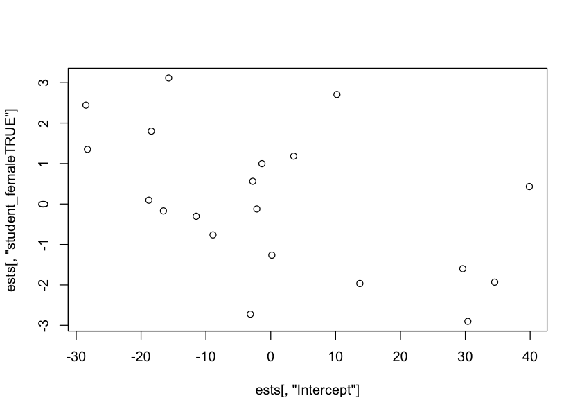

```r
(ests <- ranef(fit_2)$teacher_id[,'Estimate',])
# plot a pair of them
plot(ests[,'Intercept'], ests[,'student_femaleTRUE'])
```

## Adding second-level (group-level) predictors

Adding group-level predictors is straightforward, but a little more complex than what we've done so far. In the slides, we saw how to expand a multilevel model into a "mixed-effects" model with interactions and random components.

We will start by adding predictors just to the intercept:

$$ S_{ik} \sim \mathrm{Norm}(\mu_{ik},\sigma)\\ \mu_{ik} = \beta_{0k} + \beta_{1k}Age_i + \beta_{2k}Female_i + \beta_{3k}Black_i\\ \\ \beta_{0k} = \gamma_{00} + \gamma_{01}Size_k + \gamma_{02}Exp_i + \eta_{0k}\\ \beta_{1k} = \gamma_{10} + \eta_{1k}\\ \beta_{2k} = \gamma_{20} + \eta_{2k}\\ \beta_{3k} = \gamma_{30} + \eta_{3k}\\ $$

```r
# get class sizes and teacher experience without repeats
class_data <- unique(d[c('teacher_id','class_size','teacher_exper')])
head(class_data)
# center class size and teacher experience
d$class_size_c <- d$class_size-mean(class_data$class_size)
d$teacher_exp_c <- d$teacher_exp-mean(class_data$teacher_exp)
```

|  | teacher_id | class_size | teacher_exper |
| --- | --- | --- | --- |
| 859 | 16519906 | 22 | 14 |
| 1146 | 16921907 | 22 | 13 |
| 1405 | 16922919 | 20 | 13 |
| 1568 | 16928007 | 25 | 4 |
| 2121 | 18939605 | 17 | 11 |
| 2159 | 18939607 | 20 | 6 |

```r
m_3 <- student_reading_score ~
    student_age_s + student_re_black + student_female +
    class_size_c + teacher_exp_c +
    (1 + student_age_s + student_re_black + student_female | teacher_id)

# use Sys.time() to time how long it takes
t0 <- Sys.time()
fit_3 <- brm(
    formula=m_3,
    data=d,
    prior=c(
        set_prior("normal(500,100)",class="Intercept"),
        set_prior("normal(0,50)",class='b'),
        set_prior('lkj(2)',class='cor')
    ),
    chains=8,iter=1500,warmup=1000,cores=8,
    control=list(adapt_delta=.99)
)
t1 <- Sys.time()
t1-t0
```

```
Time difference of 1.095864 mins
```

```r
summary(fit_3)
prior_summary(fit_3)
```

```
 Family: gaussian
  Links: mu = identity; sigma = identity
Formula: student_reading_score ~ student_age_s + student_re_black + student_female + class_size_c + teacher_exp_c + (1 + student_age_s + student_re_black + student_female | teacher_id)
   Data: d (Number of observations: 398)
Samples: 8 chains, each with iter = 1500; warmup = 1000; thin = 1;
         total post-warmup samples = 4000

Group-Level Effects:
~teacher_id (Number of levels: 20)
                                             Estimate Est.Error l-95% CI
sd(Intercept)                                   25.73      6.12    15.68
sd(student_age_s)                                3.23      2.50     0.14
sd(student_re_blackTRUE)                        11.67      8.58     0.48
sd(student_femaleTRUE)                           6.05      4.60     0.21
cor(Intercept,student_age_s)                     0.12      0.37    -0.63
cor(Intercept,student_re_blackTRUE)             -0.05      0.37    -0.72
cor(student_age_s,student_re_blackTRUE)          0.01      0.38    -0.69
cor(Intercept,student_femaleTRUE)               -0.12      0.36    -0.74
cor(student_age_s,student_femaleTRUE)           -0.00      0.38    -0.70
cor(student_re_blackTRUE,student_femaleTRUE)    -0.05      0.37    -0.73
                                             u-95% CI Eff.Sample Rhat
sd(Intercept)                                   39.79       1121 1.00
sd(student_age_s)                                9.36       2046 1.00
sd(student_re_blackTRUE)                        31.95       1032 1.00
sd(student_femaleTRUE)                          17.03       2089 1.00
cor(Intercept,student_age_s)                     0.77       3759 1.00
cor(Intercept,student_re_blackTRUE)              0.67       2675 1.00
cor(student_age_s,student_re_blackTRUE)          0.70       2685 1.00
cor(Intercept,student_femaleTRUE)                0.60       3679 1.00
cor(student_age_s,student_femaleTRUE)            0.69       3389 1.00
cor(student_re_blackTRUE,student_femaleTRUE)     0.67       3502 1.00

Population-Level Effects:
                     Estimate Est.Error l-95% CI u-95% CI Eff.Sample Rhat
Intercept              529.29      7.99   513.53   544.76       1429 1.00
student_age_s           -3.12      2.67    -8.20     2.14       3317 1.00
student_re_blackTRUE   -27.81      8.23   -44.52   -12.04       2535 1.00
student_femaleTRUE       9.97      4.93     0.43    19.40       4343 1.00
class_size_c            -1.67      1.79    -5.19     1.91       1293 1.00
teacher_exp_c           -0.19      0.76    -1.68     1.38       1441 1.00

Family Specific Parameters:
      Estimate Est.Error l-95% CI u-95% CI Eff.Sample Rhat
sigma    45.35      1.68    42.21    48.79       4438 1.00

Samples were drawn using sampling(NUTS). For each parameter, Eff.Sample
is a crude measure of effective sample size, and Rhat is the potential
scale reduction factor on split chains (at convergence, Rhat = 1).
```

| prior | class | coef | group | resp | dpar | nlpar | bound |
| --- | --- | --- | --- | --- | --- | --- | --- |
| normal(0,50) | b |  |  |  |  |  |  |
|  | b | class_size_c |  |  |  |  |  |
|  | b | student_age_s |  |  |  |  |  |
|  | b | student_femaleTRUE |  |  |  |  |  |
|  | b | student_re_blackTRUE |  |  |  |  |  |
|  | b | teacher_exp_c |  |  |  |  |  |
| normal(500,100) | Intercept |  |  |  |  |  |  |
| lkj_corr_cholesky(2) | L |  |  |  |  |  |  |
|  | L |  | teacher_id |  |  |  |  |
| student_t(3, 0, 53) | sd |  |  |  |  |  |  |
|  | sd |  | teacher_id |  |  |  |  |
|  | sd | Intercept | teacher_id |  |  |  |  |
|  | sd | student_age_s | teacher_id |  |  |  |  |
|  | sd | student_femaleTRUE | teacher_id |  |  |  |  |
|  | sd | student_re_blackTRUE | teacher_id |  |  |  |  |
| student_t(3, 0, 53) | sigma |  |  |  |  |  |  |

Adding predictor variables to the slope parameters means that they have to interact with the population-level variable. (Note: if you are not including the covariates in the intercept, this gets more complicated).

$$ S_{ik} \sim \mathrm{Norm}(\mu_{ik},\sigma)\\ \mu_{ik} = \beta_{0k} + \beta_{1k}Age_i + \beta_{2k}Female_i + \beta_{3k}Black_i\\ \\ \beta_{0k} = \gamma_{00} + \gamma_{01}Size_k + \gamma_{02}Exp_i +\eta_{0k}\\ \beta_{1k} = \gamma_{10} + \gamma_{11}Size_k + \eta_{1k}\\ \beta_{2k} = \gamma_{20} + \eta_{2k}\\ \beta_{3k} = \gamma_{30} + \eta_{3k}\\ $$

```r
m_4 <- student_reading_score ~
    student_age_s*class_size + student_re_black + student_female +
    teacher_exp_c +
    (1 + student_age_s + student_re_black + student_female | teacher_id)

t0 <- Sys.time()
fit_4 <- brm(
    formula=m_4,
    data=d,
    prior=c(
        set_prior("normal(500,100)",class="Intercept"),
        set_prior("normal(0,50)",class='b'),
        set_prior('lkj(2)',class='cor')
    ),
    chains=8,iter=1500,warmup=1000,cores=8,
    control=list(adapt_delta=.99)
)
t1 <- Sys.time()
t1-t0
```

```
Time difference of 1.10233 mins
```

```r
summary(fit_4)
```

```
 Family: gaussian
  Links: mu = identity; sigma = identity
Formula: student_reading_score ~ student_age_s * class_size + student_re_black + student_female + teacher_exp_c + (1 + student_age_s + student_re_black + student_female | teacher_id)
   Data: d (Number of observations: 398)
Samples: 8 chains, each with iter = 1500; warmup = 1000; thin = 1;
         total post-warmup samples = 4000

Group-Level Effects:
~teacher_id (Number of levels: 20)
                                             Estimate Est.Error l-95% CI
sd(Intercept)                                   26.00      6.00    16.14
sd(student_age_s)                                3.45      2.59     0.14
sd(student_re_blackTRUE)                        11.28      8.19     0.46
sd(student_femaleTRUE)                           6.12      4.61     0.28
cor(Intercept,student_age_s)                     0.14      0.36    -0.60
cor(Intercept,student_re_blackTRUE)             -0.06      0.36    -0.72
cor(student_age_s,student_re_blackTRUE)          0.03      0.37    -0.69
cor(Intercept,student_femaleTRUE)               -0.11      0.37    -0.75
cor(student_age_s,student_femaleTRUE)           -0.01      0.38    -0.72
cor(student_re_blackTRUE,student_femaleTRUE)    -0.04      0.38    -0.73
                                             u-95% CI Eff.Sample Rhat
sd(Intercept)                                   39.58       1780 1.00
sd(student_age_s)                                9.60       2768 1.00
sd(student_re_blackTRUE)                        30.07       1379 1.00
sd(student_femaleTRUE)                          16.84       2463 1.00
cor(Intercept,student_age_s)                     0.76       6374 1.00
cor(Intercept,student_re_blackTRUE)              0.67       4046 1.00
cor(student_age_s,student_re_blackTRUE)          0.72       3150 1.00
cor(Intercept,student_femaleTRUE)                0.64       5307 1.00
cor(student_age_s,student_femaleTRUE)            0.71       3689 1.00
cor(student_re_blackTRUE,student_femaleTRUE)     0.67       3934 1.00

Population-Level Effects:
                         Estimate Est.Error l-95% CI u-95% CI Eff.Sample Rhat
Intercept                  566.46     39.96   485.74   643.90       1835 1.00
student_age_s               10.73     17.08   -22.67    44.63       2585 1.00
class_size                  -1.80      1.86    -5.42     1.91       1819 1.00
student_re_blackTRUE       -27.76      8.31   -44.66   -11.49       3296 1.00
student_femaleTRUE          10.30      5.00     0.44    20.16       6600 1.00
teacher_exp_c               -0.19      0.76    -1.63     1.36       2246 1.00
student_age_s:class_size    -0.64      0.77    -2.17     0.86       2568 1.00

Family Specific Parameters:
      Estimate Est.Error l-95% CI u-95% CI Eff.Sample Rhat
sigma    45.36      1.67    42.28    48.75       5779 1.00

Samples were drawn using sampling(NUTS). For each parameter, Eff.Sample
is a crude measure of effective sample size, and Rhat is the potential
scale reduction factor on split chains (at convergence, Rhat = 1).
```

With this, we can finally fit the full model: $$ S_{ik} \sim \mathrm{Norm}(\mu_{ik},\sigma)\\ \mu_{ik} = \beta_{0k} + \beta_{1k}Age_i + \beta_{2k}Female_i + \beta_{3k}Black_i\\ \\ \beta_{0k} = \gamma_{00} + \gamma_{01}Size_k + \gamma_{02}Exp_i + \gamma_{03}TeacherFemale_k+\gamma_{04}TeacherBlack_k+ \gamma_{05}PropBlack_k+\eta_{0k}\\ \beta_{1k} = \gamma_{10} + \gamma_{11}Size_k + \eta_{1k}\\ \beta_{2k} = \gamma_{20} + \gamma_{21}TeacherFemale_k + \eta_{2k}\\ \beta_{3k} = \gamma_{30} + \gamma_{31}TeacherBlack_k + \\ \phantom{{}={}}\gamma_{32}PropBlack_k+\eta_{3k} $$

```r
m_5 <- student_reading_score ~
    student_age_s*class_size_c + teacher_exp_c +
    student_female*teacher_female +
    student_re_black*teacher_re_black + student_re_black*class_prop_black +
    (1 +
        student_age_s +
        student_female +
        student_re_black
        |teacher_id)

t0 <- Sys.time()
fit_5 <- brm(
    formula=m_5,
    data=d,
    prior=c(
        set_prior("normal(500,100)",class="Intercept"),
        set_prior("normal(0,50)",class='b'),
        set_prior('lkj(2)',class='cor')
    ),
    chains=8,iter=1500,warmup=1000,cores=8,
    control=list(adapt_delta=.99)
)
t1 <- Sys.time()
t1-t0
```

```
Time difference of 1.250875 mins
```

```r
summary(fit_5)
```

```
 Family: gaussian
  Links: mu = identity; sigma = identity
Formula: student_reading_score ~ student_age_s * class_size_c + teacher_exp_c + student_female * teacher_female + student_re_black * teacher_re_black + student_re_black * class_prop_black + (1 + student_age_s + student_female + student_re_black | teacher_id)
   Data: d (Number of observations: 398)
Samples: 8 chains, each with iter = 1500; warmup = 1000; thin = 1;
         total post-warmup samples = 4000

Group-Level Effects:
~teacher_id (Number of levels: 20)
                                             Estimate Est.Error l-95% CI
sd(Intercept)                                   23.87      5.98    14.38
sd(student_age_s)                                3.43      2.64     0.14
sd(student_femaleTRUE)                           5.91      4.59     0.25
sd(student_re_blackTRUE)                        10.96      8.10     0.39
cor(Intercept,student_age_s)                     0.15      0.36    -0.58
cor(Intercept,student_femaleTRUE)               -0.10      0.37    -0.77
cor(student_age_s,student_femaleTRUE)            0.00      0.38    -0.70
cor(Intercept,student_re_blackTRUE)             -0.15      0.37    -0.79
cor(student_age_s,student_re_blackTRUE)          0.02      0.38    -0.71
cor(student_femaleTRUE,student_re_blackTRUE)    -0.02      0.38    -0.73
                                             u-95% CI Eff.Sample Rhat
sd(Intercept)                                   37.86       1742 1.00
sd(student_age_s)                                9.70       2632 1.00
sd(student_femaleTRUE)                          17.05       2451 1.00
sd(student_re_blackTRUE)                        30.36       1532 1.00
cor(Intercept,student_age_s)                     0.77       4850 1.00
cor(Intercept,student_femaleTRUE)                0.65       5157 1.00
cor(student_age_s,student_femaleTRUE)            0.71       4801 1.00
cor(Intercept,student_re_blackTRUE)              0.59       4181 1.00
cor(student_age_s,student_re_blackTRUE)          0.74       3484 1.00
cor(student_femaleTRUE,student_re_blackTRUE)     0.68       3165 1.00

Population-Level Effects:
                                          Estimate Est.Error l-95% CI u-95% CI
Intercept                                   536.90     50.20   439.43   634.85
student_age_s                                -2.31      2.82    -7.88     3.16
class_size_c                                 -2.31      1.76    -5.71     1.18
teacher_exp_c                                -0.09      0.71    -1.48     1.34
student_femaleTRUE                            5.46     34.58   -62.94    74.03
teacher_femaleTRUE                           -0.25     49.32   -96.06    96.36
```

[output cut: 14 more lines]

```
student_re_blackTRUE                            3036 1.00
teacher_re_blackTRUE                            2979 1.00
class_prop_black                                2228 1.00
student_age_s:class_size_c                      4374 1.00
student_femaleTRUE:teacher_femaleTRUE           3067 1.00
student_re_blackTRUE:teacher_re_blackTRUE       2744 1.00
student_re_blackTRUE:class_prop_black           2041 1.00

Family Specific Parameters:
      Estimate Est.Error l-95% CI u-95% CI Eff.Sample Rhat
sigma    45.40      1.66    42.27    48.93       6545 1.00

Samples were drawn using sampling(NUTS). For each parameter, Eff.Sample
is a crude measure of effective sample size, and Rhat is the potential
scale reduction factor on split chains (at convergence, Rhat = 1).
```

## Generalized models

As a brief example of using `brm()` to estimate *generalized* multilevel models (binomial, poisson, multinomial, etc.), we will specify a simple model predicting whether a student does better on their math test than their reading test (a binary outcome):

$$ M_{ik} \sim \mathrm{Binomial}(1,p_{ik})\\ \mathrm{logit}(p_{ik}) = \beta_{0k} + \beta_{1k}Age_i + \beta_{2k}Female_i\\ \\ \beta_{0k} = \gamma_{00} + \gamma_{01}TExp_k + \gamma_{02}TFemale_k \eta_{0k}\\ \beta_{1k} = \gamma_{10} + \eta_{1k}\\ \beta_{2k} = \gamma_{20} + \eta_{2k} $$

```r
# create the outcome variable
d$student_math_higher <- d$student_math_score > d$student_reading_score
table(d$student_math_higher)
```

```
FALSE  TRUE
  166   231
```

```r
m_6 <- student_math_higher ~
    student_age_s + student_female +
    teacher_exp_c + teacher_female +
    (1 + student_age_s + student_female | teacher_id)

t0 <- Sys.time()
fit_6 <- brm(
    formula=m_6,
    data=d,
    family='bernoulli',
    prior=c(
        set_prior("normal(500,100)",class="Intercept"),
        set_prior("normal(0,50)",class='b'),
        set_prior('lkj(2)',class='cor')
    ),
    chains=8,iter=1500,warmup=1000,cores=8,
    control=list(adapt_delta=.99)
)
t1 <- Sys.time()
t1-t0
```

```
Time difference of 47.61051 secs
```

The only addition to the `brm()` call is the new `family` argument. By specifying a Bernoulli distribution, the model assumes the link function will be logit. You can specify different link functions and different outcome distributions. For a list of possible models see `?brmsfamily`. (Note: the ordered logistic regression is called "cumulative" in the `brms` framework).

```r
summary(fit_6)
```

```
 Family: bernoulli
  Links: mu = logit
Formula: student_math_higher ~ student_age_s + student_female + teacher_exp_c + teacher_female + (1 + student_age_s + student_female | teacher_id)
   Data: d (Number of observations: 397)
Samples: 8 chains, each with iter = 1500; warmup = 1000; thin = 1;
         total post-warmup samples = 4000

Group-Level Effects:
~teacher_id (Number of levels: 20)
                                      Estimate Est.Error l-95% CI u-95% CI
sd(Intercept)                             1.11      0.27     0.66     1.73
sd(student_age_s)                         0.21      0.16     0.01     0.59
sd(student_femaleTRUE)                    0.39      0.29     0.02     1.08
cor(Intercept,student_age_s)             -0.11      0.39    -0.79     0.65
cor(Intercept,student_femaleTRUE)        -0.04      0.39    -0.75     0.73
cor(student_age_s,student_femaleTRUE)     0.05      0.41    -0.74     0.79
                                      Eff.Sample Rhat
sd(Intercept)                               1381 1.00
sd(student_age_s)                           1747 1.00
sd(student_femaleTRUE)                      1417 1.00
cor(Intercept,student_age_s)                4130 1.00
cor(Intercept,student_femaleTRUE)           4301 1.00
cor(student_age_s,student_femaleTRUE)       2689 1.00

Population-Level Effects:
                   Estimate Est.Error l-95% CI u-95% CI Eff.Sample Rhat
Intercept              0.30     51.69  -100.52   100.29       6100 1.00
student_age_s          0.08      0.13    -0.18     0.35       3990 1.00
student_femaleTRUE    -0.60      0.26    -1.10    -0.08       4028 1.00
teacher_exp_c          0.04      0.03    -0.03     0.10       1632 1.00
teacher_femaleTRUE     0.42     51.69   -99.43   101.39       6103 1.00

Samples were drawn using sampling(NUTS). For each parameter, Eff.Sample
is a crude measure of effective sample size, and Rhat is the potential
scale reduction factor on split chains (at convergence, Rhat = 1).
```